# A549-HBE-ALI comparison analysis

## Alignment and DEA

**Raw datasets:** A549, primary hBECs (submersion culture, HBE), and primary hBECs (air-liquid interface culture, ALI) treated with IL1B, glucocorticoid, or both at 6h. This is actually three experiments at different timepoints, so for now we use their shared timepoint (6 h post-treatment).

Alignment performed with kallisto version 0.46.1 and normalization/DEA performed with sleuth version something on the cluster. Everything documented in `kallisto-sleuth.md`. I used individual sleuth runs for each cell type, modeled as `~treatment`. Effect sizes (“log2fold”) and FDR are from Wald test using unstimulated (NS) samples as baseline. I also modeled everything together under model `~treatment*condition` for interaction testing. Finally, raw tpm values were extracted.

Example univariate DEA data (~treatment)

| Gene | celltype | treatment | time | log2fold | FDR |
| --- | --- | --- | --- | --- | --- |
| NFKBIA | A549 | IL1B | 6h | 3.0341219 | 0.0000000 |
| NFKBIA | A549 | GC | 6h | 2.2055382 | 0.0000000 |
| NFKBIA | A549 | combo | 6h | 3.0864520 | 0.0000000 |
| NFKBIA | ALI | IL1B | 6h | 3.0640979 | 0.0000000 |
| NFKBIA | ALI | GC | 6h | 0.5737987 | 0.7668408 |
| NFKBIA | ALI | combo | 6h | 3.1271927 | 0.0000000 |
| NFKBIA | HBE | IL1B | 6h | 1.6700219 | 0.0000008 |
| NFKBIA | HBE | GC | 6h | 0.5918173 | 0.8067702 |
| NFKBIA | HBE | combo | 6h | 1.9126890 | 0.0000000 |

| Gene | lrt_FDR | ALI_IL1B_diff | ALI_IL1B_FDR | HBE_IL1B_diff | HBE_IL1B_FDR | ALI_GC_diff | ALI_GC_FDR | HBE_GC_diff | HBE_GC_FDR | ALI_combo_diff | ALI_combo_FDR | HBE_combo_diff | HBE_combo_FDR |
| --- | --- | --- | --- | --- | --- | --- | --- | --- | --- | --- | --- | --- | --- |
| IRAK3 | 0.00e+00 | -2.7730331 | 0.0000000 | -3.615402 | 0.0000000 | -5.024278 | 0.0000000 | -4.243510 | 0.0000000 | -5.0891347 | 0.0000000 | -5.199215 | 0.0000000 |
| NFKBIA | 2.50e-06 | -0.0081513 | 0.9953362 | -1.347587 | 0.0048081 | -1.624309 | 0.0010009 | -1.594663 | 0.0012972 | 0.0704543 | 0.9717566 | -1.146222 | 0.0357046 |
| TNFAIP3 | 5.07e-05 | -3.4185435 | 0.0000528 | -3.371705 | 0.0000718 | -1.738957 | 0.2649870 | -2.900867 | 0.0026622 | -2.7622790 | 0.0025900 | -3.342315 | 0.0001313 |

Example tpm data, first 20 rows for representative gene

| Gene | rep | celltype | treatment | time | tpm | log2tpm | fold | log2fold |
| --- | --- | --- | --- | --- | --- | --- | --- | --- |
| NFKBIA | R1 | A549 | NS | 6 | 40.04168 | 5.327029 | 1.000000 | 0.000000 |
| NFKBIA | R2 | A549 | NS | 6 | 41.81913 | 5.389537 | 1.000000 | 0.000000 |
| NFKBIA | R3 | A549 | NS | 6 | 41.59516 | 5.381808 | 1.000000 | 0.000000 |
| NFKBIA | R4 | A549 | NS | 6 | 34.95151 | 5.131405 | 1.000000 | 0.000000 |
| NFKBIA | R1 | A549 | IL1B | 6 | 310.19487 | 8.277496 | 7.729992 | 2.950467 |
| NFKBIA | R2 | A549 | IL1B | 6 | 303.63668 | 8.246677 | 7.245777 | 2.857140 |
| NFKBIA | R3 | A549 | IL1B | 6 | 338.65023 | 8.404078 | 8.124449 | 3.022270 |
| NFKBIA | R4 | A549 | IL1B | 6 | 293.10354 | 8.195759 | 8.364933 | 3.064354 |
| NFKBIA | R1 | A549 | GC | 6 | 182.44554 | 7.512113 | 4.547531 | 2.185084 |
| NFKBIA | R2 | A549 | GC | 6 | 184.85575 | 7.531036 | 4.412204 | 2.141499 |
| NFKBIA | R3 | A549 | GC | 6 | 196.77518 | 7.621137 | 4.721775 | 2.239329 |
| NFKBIA | R4 | A549 | GC | 6 | 156.80796 | 7.293775 | 4.476496 | 2.162370 |
| NFKBIA | R1 | A549 | combo | 6 | 324.53280 | 8.342665 | 8.087176 | 3.015636 |
| NFKBIA | R2 | A549 | combo | 6 | 331.03845 | 8.371291 | 7.899458 | 2.981754 |
| NFKBIA | R3 | A549 | combo | 6 | 331.14040 | 8.371735 | 7.944337 | 2.989927 |
| NFKBIA | R4 | A549 | combo | 6 | 304.50374 | 8.250790 | 8.690174 | 3.119385 |
| NFKBIA | donor57 | ALI | NS | 6 | 121.70039 | 6.928375 | 1.000000 | 0.000000 |
| NFKBIA | donor78 | ALI | NS | 6 | 56.69021 | 5.827570 | 1.000000 | 0.000000 |
| NFKBIA | donor82 | ALI | NS | 6 | 39.45922 | 5.305942 | 1.000000 | 0.000000 |
| NFKBIA | donor86 | ALI | NS | 6 | 35.42983 | 5.150959 | 1.000000 | 0.000000 |

## IN PROGRESS: Understanding individual variation in gene expression

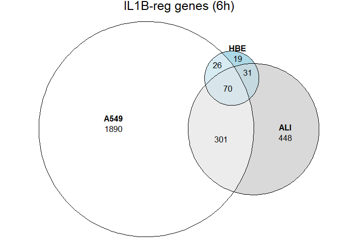

One possible reason: A549s are derived from one individual, so four sequencing replicates may have low variability + higher significance. Each sequencing replicate for primary cells is a different individual, so higher variability + lower significance. Ignoring FDR entirely (i.e., only using the abs(log2fold) >= 1 threshold), A549 and primary cells actually have similarly sized regulated gene pools (panel A). In A549s, variation in tpm-derived log2fold values tend to be lower (panel B) and a greater proportion of the rep pool meets log2fold thresholds (panel C).

*Fixed problem 040626: discrepancy between Venn and spread gene counts.*

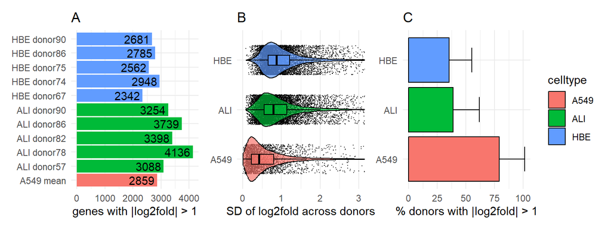

**Where does each primary donor sit in relation to A549?** For each primary cell donor, check overlap of log2fold-threshold-meeting genes in that donor **(white)** vs A549 cells **(grey)**. Plots are also tagged with Jaccard index **(J)** and total number of genes **(n, union size)**

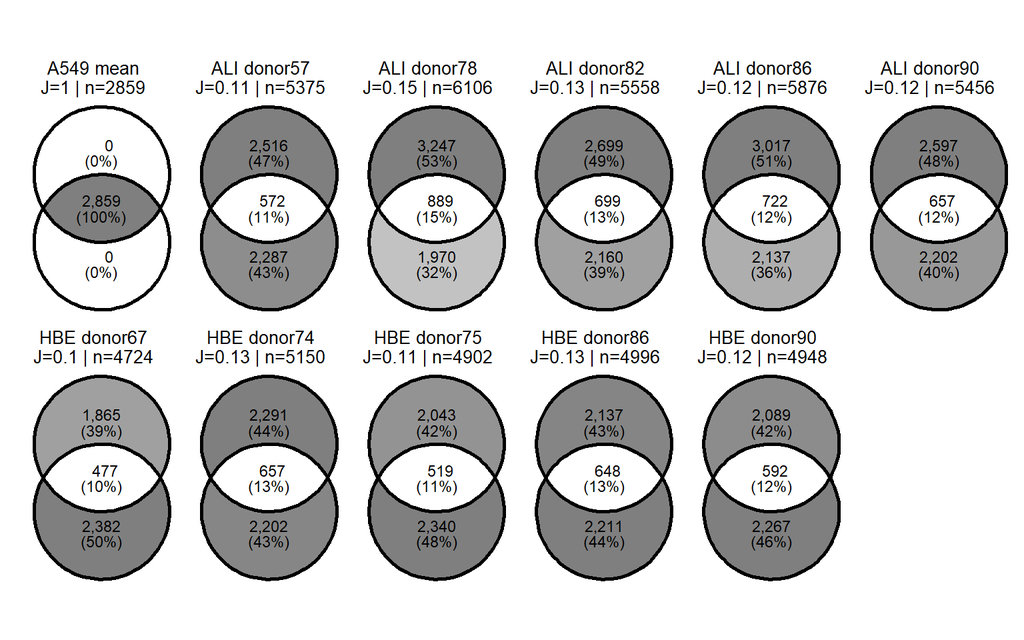

**Where do primary donors sit in relation to each other?** This is technically a 10-way comparison so Venns no longer work – use an UpSet plot instead. Panel A is the intersect between *all donors and A549*, B is the intersect between *donors only*. Notice 70 genes shared between all donors (B), where 54 of these are also shared with A549 (A).

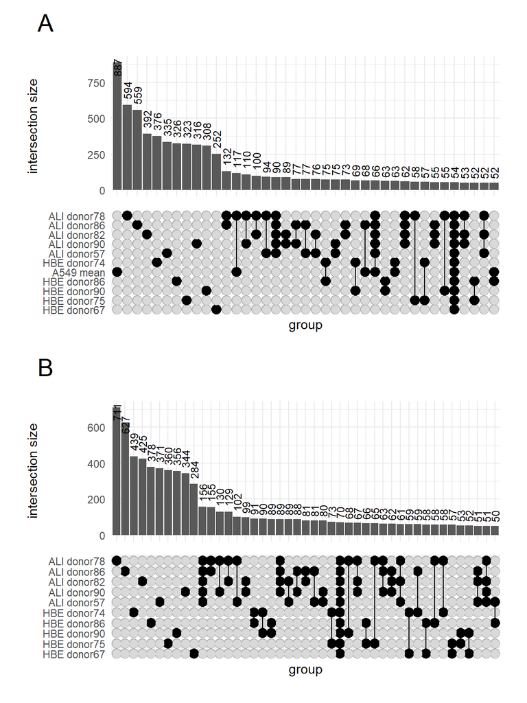

54 “universally” shared genes from above:

```
##  [1] "ABTB2"    "APOBEC3A" "BCL2A1"   "C1QTNF1"  "CCL20"    "CD83"
##  [7] "CHST2"    "CSF3"     "CXCL1"    "CXCL2"    "CXCL3"    "CXCL5"
## [13] "CXCL6"    "CXCL8"    "DEFB4B"   "EBI3"     "GBP2"     "GFPT2"
## [19] "ICAM1"    "IDO1"     "IL23A"    "IL32"     "IL36G"    "IL4I1"
## [25] "IRAK2"    "KYNU"     "LTB"      "MAP2K3"   "MMP13"    "MMP7"
## [31] "NEURL3"   "NFKB2"    "NFKBIA"   "NFKBIE"   "NFKBIZ"   "NINJ1"
## [37] "NOS2"     "PGLYRP4"  "PI3"      "PLAT"     "RELB"     "SERPINA3"
## [43] "SGPP2"    "SOD2"     "STAT5A"   "TMPRSS2"  "TNF"      "TNFAIP2"
## [49] "TNFAIP3"  "TNFAIP6"  "UBASH3A"  "VNN3P"    "ZC3H12A"  "ZC3H12C"
```

70 donor-shared genes from above:

```
##  [1] "ABTB2"    "APOBEC3A" "BCL2A1"   "C1QTNF1"  "CCL20"    "CD83"
##  [7] "CHST2"    "CSF3"     "CXCL1"    "CXCL2"    "CXCL3"    "CXCL5"
## [13] "CXCL6"    "CXCL8"    "DEFB4B"   "EBI3"     "GBP2"     "GFPT2"
## [19] "ICAM1"    "IDO1"     "IL23A"    "IL32"     "IL36G"    "IL4I1"
## [25] "IRAK2"    "KYNU"     "LTB"      "MAP2K3"   "MMP13"    "MMP7"
## [31] "NEURL3"   "NFKB2"    "NFKBIA"   "NFKBIE"   "NFKBIZ"   "NINJ1"
## [37] "NOS2"     "PGLYRP4"  "PI3"      "PLAT"     "RELB"     "SERPINA3"
## [43] "SGPP2"    "SOD2"     "STAT5A"   "TMPRSS2"  "TNF"      "TNFAIP2"
## [49] "TNFAIP3"  "TNFAIP6"  "UBASH3A"  "VNN3P"    "ZC3H12A"  "ZC3H12C"
## [55] "DEFB4A"   "GPR68"    "IL17C"    "IL1R2"    "IL36A"    "PRRX2"
## [61] "RND1"     "SEMA7A"   "SGK1"     "SLC28A3"  "SPRR2A"   "SPRR2E"
## [67] "SPRR2F"   "TGM5"     "TLR2"     "ZG16B"
```